# MTH6139 Time Series

## 3 Understanding trends with linear regression

To establish a baseline understanding of Tata Motors’ stock price growth, let’s apply a simple linear regression model.

```r
lm_model <- lm(y ~ ds, data=df)
summary(lm_model)
```

```
##
## Call:
## lm(formula = y ~ ds, data = df)
##
## Residuals:
##    Min     1Q Median     3Q    Max
## -187.8 -126.5  -48.2  112.3  400.2
##
## Coefficients:
##               Estimate Std. Error t value Pr(>|t|)
## (Intercept)  1.051e+02  5.195e+02   0.202    0.840
## ds          -1.307e-04  7.280e-04  -0.180    0.858
##
## Residual standard error: 158.8 on 4623 degrees of freedom
## Multiple R-squared:  6.973e-06,  Adjusted R-squared:  -0.0002093
## F-statistic: 0.03224 on 1 and 4623 DF,  p-value: 0.8575
```

Key Insights:

The slope of the regression model indicates long-term growth or decline.

The R-squared value shows how well the trend explains the stock’s movements.

### Visualizing the Linear Trend

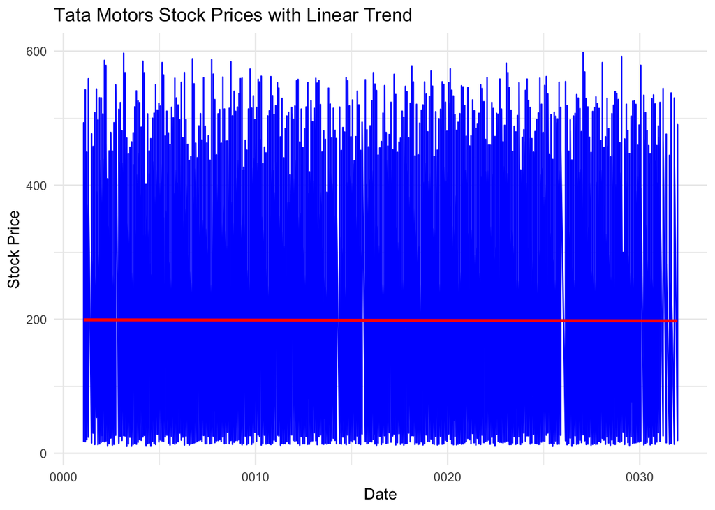

```r
ggplot(df, aes(x=ds, y=y)) +
    geom_line(color="blue") +
    geom_smooth(method="lm", col="red", se=FALSE) +
    labs(title="Tata Motors Stock Prices with Linear Trend", x="Date", y="Stock Price") +
    theme_minimal()
```

## 4 Prophet Model for Stock forecasting

### 4.1 Basic Prophet Model

```r
#Initialise Basic Prophet Model
model_basic <- prophet(df)
```

```
## Disabling weekly seasonality. Run prophet with weekly.seasonality=TRUE to override this.
```

```
## Disabling daily seasonality. Run prophet with daily.seasonality=TRUE to override this.
```

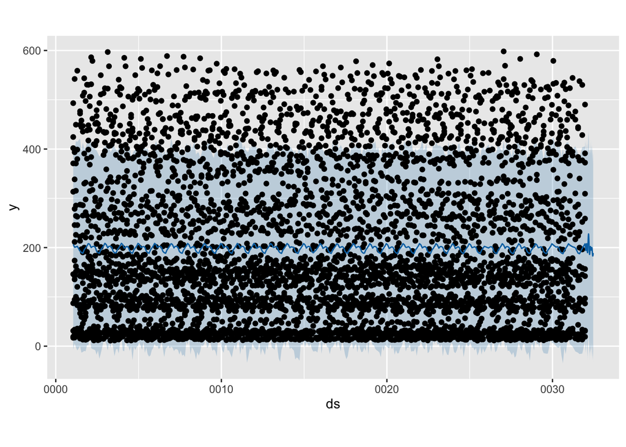

```r
#Create Future DataFrame (Next 180 Days)
future_basic <- make_future_dataframe(model_basic, periods = 180)

#Generate Forecast
forecast_basic <- predict(model_basic, future_basic)

#Plot Basic Forecasted Results
plot(model_basic, forecast_basic)
```

Interpretation:

The Basic Prophet Model forecast for Tata Motors’ stock prices shows a **blue line** representing the **predicted trend** and a **shaded blue area** indicating the **confidence interval**. The **black dots** indicating **actual stock price**, show severe variations and high volatility, indicating that while the model is able to capture the general trend, it is unable to account for abrupt changes in the market. The forecasts stay largely consistent, which can suggest that the model is depending more on long-term patterns than reacting to short-term price swings. For improved accuracy, more tweaking (such as seasonality changes) would be required which is not captured by the basic model.

### 4.2 Advanced prophet model with seasonality

To improve accuracy, we enable yearly and weekly seasonality, which accounts for recurring patterns in stock price movements.

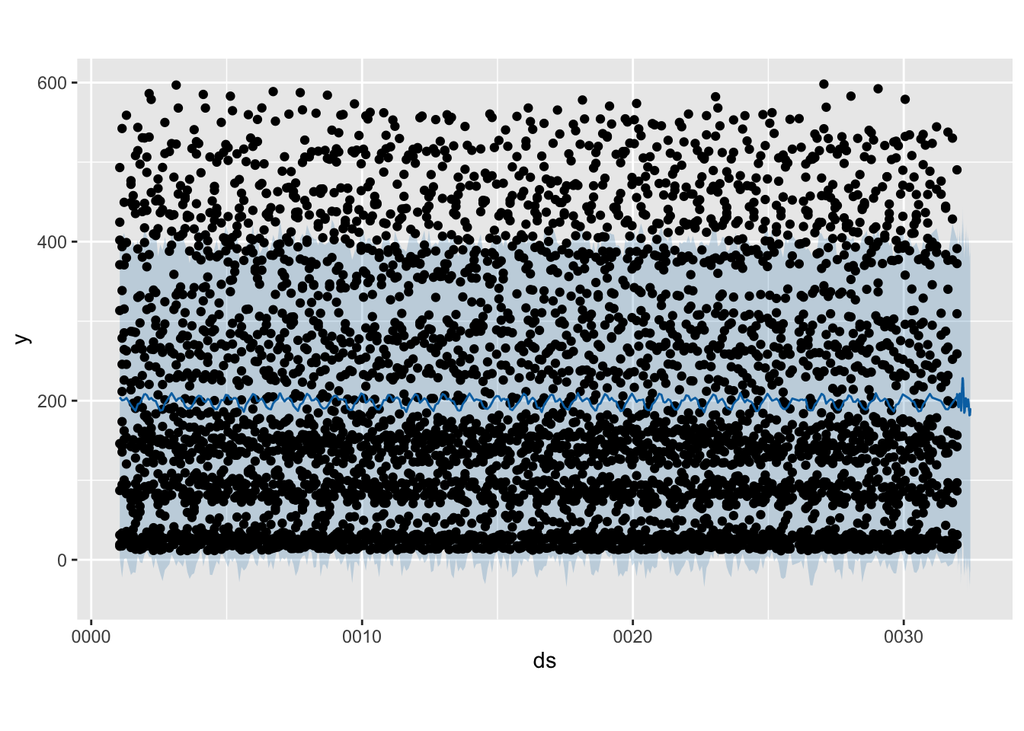

```r
# Initialise Advanced Prophet Model
model_advanced <- prophet(
    df,
    yearly.seasonality = TRUE,
    weekly.seasonality = TRUE,
    daily.seasonality = FALSE,
    n.changepoints = 5
)
# Create Future DataFrame (Next 180 Days)
future_advanced <- make_future_dataframe(model_advanced, periods = 180)

# Generate Forecast
forecast_advanced <- predict(model_advanced, future_advanced)

# Plot Advanced Forecast
plot(model_advanced, forecast_advanced)
```

# 5 Trend and seasonality analysis

Prophet allows us to decompose stock prices into trends and seasonal patterns.

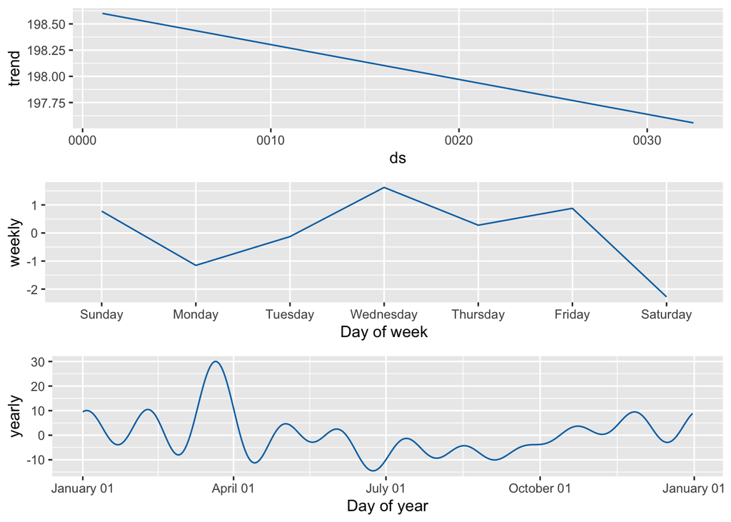

```r
# Prophet Components Plot (Trend, Seasonality, Holidays)
prophet_plot_components(model_advanced, forecast_advanced)
```

Interpretation:

*Trend Analysis*: The top graph shows a gradual downward trend, indicating a slight decline in Tata Motors’ stock prices over time. This could be due to market fluctuations, investor sentiment, or external economic conditions.

*Weekly Seasonality*: According to the middle graph, stock prices often exhibit lower values on Mondays and Saturdays and higher values on Wednesdays and Fridays. This pattern could be linked to trading activity and market sentiment.

*Yearly Seasonality*: The bottom graph shows the stock price peaks around April and December, indicating that price changes during these times are influenced by seasonal factors, corporate earnings releases, or macroeconomic developments.